# Santa Clara County Educational Attainment Indicators

[figure not shown]

The map below shows discrepancies of up to 9% in between adjacent geographic areas in SCC. Interestingly, the center of San Jose has a lower percentage of students without internet access–this analysis can be extended more broadly to identify if it is a pattern. These discrepancies point to the difficulties of transitioning to remote learning for a small percentage of K-12 students. These discrepancies may indicate compounding inequities for this subset of students (secure housing, financial stability, presence of caregivers at home). This map is an initial dive into persisting educational disparities. To help inform funding priorities regarding internet access, a more specific and comprehensive analysis would be of use.

### % K-12 Student Internet Access

[interactive chart not shown]

This graph shows the percent change across educational outcomes, from high school graduates to 4-year college graduates, broken down by race for Santa Clara county (SCC). The Asian population in SCC has the greatest percent change out of any racial group; yet, are many disparities between different Asian communities based on ethnicity (e.g. Southeast Asian and East Asian communities), that this graph’s data set (ACS) lacks. The negative percent changes for the Indigenous populations in SCC is concerning. There is a clear discrepancy in education attainment between Indigenous groups and other racial groups, at least in terms of higher education, and the causes are complex. Code for this dashboard: https://github.com/natram3/natram3.github.io/blob/master/R-9.Rmd

### % Change From High School Graduates to Bachelor’s Degrees

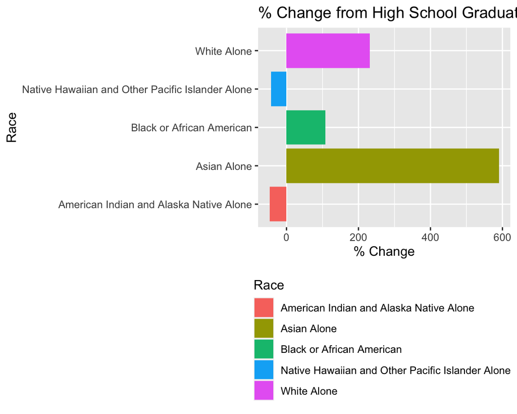